### Data source

The police service calls data was obtained from the [City of Orlando Open Data website](https://data.cityoforlando.net/Orlando-Police/OPD-Calls-for-Service-Data-Lens/uum9-29mz)

### Basic usage

Either type a location’s address or click on the map to obtain results in a radius around that location. You can further filter the data by police call category, day of week, or period of the day. You can also facet the plots by category, day, or period.

### Map tab

The map tab displays all the police calls according to the options selected on the left panel. The map is initially centered at a location chosen at random from a set of landmarks and intersections.

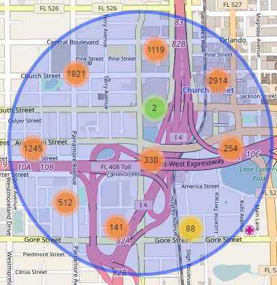

Zooming in and clicking on an individual marker will show the address, description, and date and time of the incident.

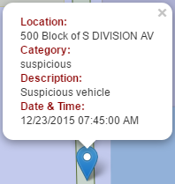

### Data tab

Here you can view the results 25 at a time, as well as interactively filter and search and sort them.

### Bar plots tab

The bar plots (and the density maps) are faceted according to the input selection. In order to keep the tables readable, the top six police calls categories are used.

The following shows a result of police calls on Mondays, Wednesdays, and Fridays that took place during the early morning and evening time periods, faceted by day of the week

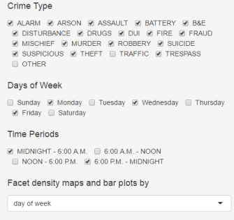

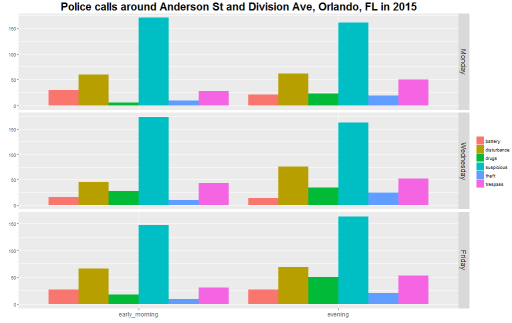

The same results, now faceted by time of day

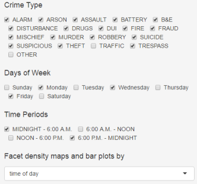

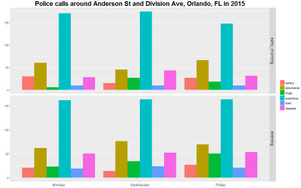

### Density maps tab

The density maps take a few seconds to display. They are faceted similarly to the bar plots

[figure not shown]

### Table tab

The table depicts a 3-way contingency table. The variables (category, day of the week, and period of the day) are also arranged depending on the facets chosen on the left panel.

### References

1. Orlando Police Department. (2016). *OPD Calls for Service Data* [CSV]. Retrieved from https://data.cityoforlando.net/Orlando-Police/OPD-Calls-for-Service-Data-Lens/uum9-29mz
2. Hillsborough County Sheriff’s Office. *Hillsborough County Crime Map*. Retrieved from http://gis.hcso.tampa.fl.us/crimemapping/
3. Chow, Jo-fai. (2014, March 11). *Introducing ‘CrimeMap’*. Retrieved from http://www.jofaichow.co.uk/2014_03_11_LondonR/#1
4. Chang, Winston. *Cookbook for R*. Sebastopol: O’Reilly Media, 2013. Retrieved from http://www.cookbook-r.com/
5. Matloff, Norman. *The Art of R Programming*. San Francisco: No Starch Press, 2011. PDF.
6. Adler, Joseph. *R in a Nutshell, Second Edition*. Sebastopol: O’Reilly Media, 2012. PDF.
7. D. Kahle and H. Wickham. *ggmap: Spatial Visualization with ggplot2*. The R Journal, 5(1), 144-161. URL http://journal.r-project.org/archive/2013-1/kahle-wickham.pdf
8. Veness, Chris. *Calculate distance, bearing and more between Latitude/Longitude points*. Retrieved from http://www.movable-type.co.uk/scripts/latlong.html
9. Roger Peng. *Computing for Data Analysis*, Spring 2014. Coursera.
10. Shiny Articles. Retrieved from http://shiny.rstudio.com/articles/
11. Samarasa and Jarpal. *Fixing the order of facets in ggplot*. Retrieved from http://stackoverflow.com/questions/14262497/fixing-the-order-of-facets-in-ggplot
12. Stein, Jonas and Muspratt, Sandy. *What does size really mean in geom_point?* Retrieved from http://stackoverflow.com/questions/13548321/what-does-size-really-mean-in-geom-point
13. Galilean Moons and Tyler Rinker. *Convert 12 hour character time to 24 hour* Retrieved from http://stackoverflow.com/questions/29833538/convert-12-hour-character-time-to-24-hour
14. alittleboy and G. Grothendieck. *extract a substring in R according to a pattern* Retrieved from http://stackoverflow.com/questions/17215789/extract-a-substring-in-r-according-to-a-pattern
15. endmemo. *R sub Function* Retrieved from http://www.endmemo.com/program/R/sub.php
16. Tor and Shane. *Suppress one command’s output in R* Retrieved from http://stackoverflow.com/questions/2723034/suppress-one-commands-output-in-r
17. Alphaneo and Dirk Eddelbuettel. *Global variables in R* Retrieved from http://stackoverflow.com/questions/1236620/global-variables-in-r
18. Eduardo Ariño de la Rubia and Sheila Doshi. *A Huge Debate: R vs. Python for Data Science* [Video] Retrieved from https://blog.dominodatalab.com/video-huge-debate-r-vs-python-data-science/
19. EliteDataScience. *R vs Python for Data Science: Summary of Modern Advances* Retrieved from https://elitedatascience.com/r-vs-python-for-data-science
20. LostLin and Tommy. *switch() statement usage* Retrieved from http://stackoverflow.com/questions/7825501/switch-statement-usage
21. kay. *Embedding Image in Shiny App* Retrieved from http://stackoverflow.com/questions/21996887/embedding-image-in-shiny-app